# SQL Data Cleaning Project

#### In This project, I use SQL to clean a salary dataset obtained from:

https://www.askamanager.org/2021/04/how-much-money-do-you-make-4.html.

#### Users enter professional information into a questionnaire. Some answers require users to check one answer out of several factor levels, while other answers allow users to input their own text. This creates some very messy data.

```python
import pandas as pd
import sqlite3
import dask.dataframe as dd
import matplotlib.pyplot as plt
```

```python
%load_ext sql
%sql sqlite:///portfolioprojects.db
```

```python
%%sql

DROP TABLE survey;
```

```
 * sqlite:///portfolioprojects.db
Done.
```

```
[]
```

```python
df = pd.read_csv('occupationsurvey.csv')
```

```python
cnn = sqlite3.connect('portfolioprojects.db')
```

```python
df.to_sql('survey', cnn)
```

```
27976
```

### Column Name Inspection

#### An initial review depicts that column names are in an unusable format. These need to be abbreviated to a level that is easier to use during the data cleaning process.

```python
%%sql

SELECT *
FROM survey
LIMIT 1;
```

```
 * sqlite:///portfolioprojects.db
Done.
```

| index | Timestamp | How old are you? | What industry do you work in? | Job title | If your job title needs additional context, please clarify here: | What is your annual salary? (You'll indicate the currency in a later question. If you are part-time or hourly, please enter an annualized equivalent -- what you would earn if you worked the job 40 hou… | How much additional monetary compensation do you get, if any (for example, bonuses or overtime in an average year)? Please only include monetary compensation here, not the value of benefits. | Please indicate the currency | If "Other," please indicate the currency here: | If your income needs additional context, please provide it here: | What country do you work in? | If you're in the U.S., what state do you work in? | What city do you work in? | How many years of professional work experience do you have overall? | How many years of professional work experience do you have in your field? | What is your highest level of education completed? | What is your gender? | What is your race? (Choose all that apply.) |
| --- | --- | --- | --- | --- | --- | --- | --- | --- | --- | --- | --- | --- | --- | --- | --- | --- | --- | --- |
| 0 | 4/27/2021 11:02 | 25-34 | Education (Higher Education) | Research and Instruction Librarian | None | 55,000 | 0.0 | USD | None | None | United States | Massachusetts | Boston | 5-7 years | 5-7 years | Master's degree | Woman | White |

```python
%%sql
ALTER TABLE survey
RENAME COLUMN "How old are you?" TO "Age";
```

```
 * sqlite:///portfolioprojects.db
Done.
```

```
[]
```

```python
%%sql

ALTER TABLE survey
RENAME COLUMN 'What industry do you work in?' TO 'Industry';

AlTER TABLE survey
RENAME COLUMN 'Job title' TO 'Job';

ALTER TABLE survey
RENAME COLUMN 'If your job title needs additional context, please clarify here:' TO 'Job_Description';
```

```
 * sqlite:///portfolioprojects.db
Done.
Done.
Done.
```

```
[]
```

```python
%%sql

ALTER TABLE survey
RENAME COLUMN "What is your annual salary? (You'll indicate the currency in a later question. If you are part-time or hourly, please enter an annualized equivalent -- what you would earn if you worked the job 40 hours a week, 52 weeks a year.)" TO 'Salary';

ALTER TABLE survey
RENAME COLUMN 'How much additional monetary compensation do you get, if any (for example, bonuses or overtime in an average year)? Please only include monetary compensation here, not the value of benefits.' TO 'Annual_Bonus';

ALTER TABLE survey
RENAME COLUMN 'Please indicate the currency' TO 'Currency';
```

```
 * sqlite:///portfolioprojects.db
Done.
Done.
Done.
```

```
[]
```

```python
%%sql


ALTER TABLE survey
RENAME COLUMN 'If your income needs additional context, please provide it here:' TO 'Income_Details';

ALTER TABLE survey
RENAME COLUMN 'What country do you work in?' TO 'Country';

ALTER TABLE survey
RENAME COLUMN "If you're in the U.S., what state do you work in?" TO 'State';

ALTER TABLE survey
RENAME COLUMN "What city do you work in?" TO 'City';

ALTER TABLE survey
RENAME COLUMN "How many years of professional work experience do you have overall?" TO 'Overall_Experience';

ALTER TABLE survey
RENAME COLUMN "How many years of professional work experience do you have in your field?" TO 'Industry_Experience';

ALTER TABLE survey
RENAME COLUMN "What is your highest level of education completed?" TO 'Education';

ALTER TABLE survey
RENAME COLUMN "What is your gender?" TO 'Gender';

ALTER TABLE survey
RENAME COLUMN "What is your race? (Choose all that apply.)" TO 'Race';
```

```
 * sqlite:///portfolioprojects.db
Done.
Done.
Done.
Done.
Done.
Done.
Done.
Done.
Done.
```

```
[]
```

#### A problem I ran into was the column titled:

'If "Other," please indicate the currency here:'

#### Since OTHER has quotations around it, SQLite was having a hard time identifying it as a column name. This problem would require me to edit the column name in something like Excel and then reloading it back into my engine. But, for the meantime, I am going to leave it as is and fix it within a follow-up project.

```python
%%sql

SELECT *
FROM survey
LIMIT 1;
```

```
 * sqlite:///portfolioprojects.db
Done.
```

| index | Timestamp | Age | Industry | Job | Job_Description | Salary | Annual_Bonus | Currency | If "Other," please indicate the currency here: | Income_Details | Country | State | City | Overall_Experience | Industry_Experience | Education | Gender | Race |
| --- | --- | --- | --- | --- | --- | --- | --- | --- | --- | --- | --- | --- | --- | --- | --- | --- | --- | --- |
| 0 | 4/27/2021 11:02 | 25-34 | Education (Higher Education) | Research and Instruction Librarian | None | 55,000 | 0.0 | USD | None | None | United States | Massachusetts | Boston | 5-7 years | 5-7 years | Master's degree | Woman | White |

## Currency and Age

#### Now, I get into inspecting the data within the table. The first column I looked at was currency. The questionnaire only offered these factor levels as a selection, so the data is not messed up here. Same with the next column of Age.

```
 * sqlite:///portfolioprojects.db
Done.
```

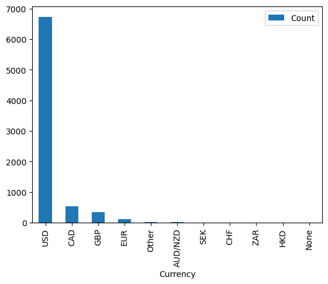

```python
currency_raw = %sql SELECT Currency, COUNT(Currency) AS Count FROM survey GROUP BY Currency ORDER BY Count DESC;

currency_raw_df = currency_raw.DataFrame()

currency_raw_df.plot('Currency', 'Count', kind='bar')
plt.show()
```

```
 * sqlite:///portfolioprojects.db
Done.
```

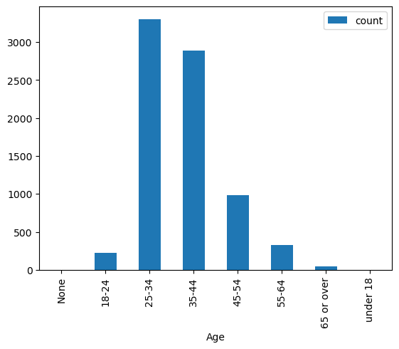

```python
age_raw = %sql SELECT Age, COUNT(Age) AS count FROM survey GROUP BY Age;

age_raw_df = age_raw.DataFrame()

age_raw_df.plot('Age', 'count', kind='bar')
plt.show()
```

## Industry

#### The next column, Industry, has almost 500 distinct values. The questionnaire offered significantly less options than that, but there was an option at the bottom for user-input text. People went crazy with this one.

#### I want this data to be usable for factor analysis, especially within this category. My goal here is to aggregate the distinct values of industry together as best I can.

```python
%%sql
SELECT COUNT(DISTINCT Industry) AS 'Number of Unique Industry Entries'
FROM survey;
```

```
 * sqlite:///portfolioprojects.db
Done.
```

| Number of Unique Industry Entries |
| --- |
| 497 |

#### A quick inspection of the counts of each industry value reveal that many of the distinct industry values are simply misspellings and misrenderings of similar industries. I can aggregate these together by using the LIKE function in SQL and labeling them with a corrected format.

#### While this method is easier than changing each industry by hand, it is by no means the most efficient way.

#### A quicker method would have been to create a new column with the LAG of the industry column, and then run a DIFFERENCE function between the two. If the difference value equals 4 (meaning they are phonetically identical), then I could aggregate them under the same Industry label. Since SQLite does not offer these functions, this is something I will do in a future project.

```python
industry_raw = %sql SELECT Industry, COUNT(Industry) AS Count FROM survey GROUP BY Industry;
industry_raw_df = industry_raw.DataFrame()

industry_list = industry_raw_df['Industry'].tolist()
print(industry_list)
```

```
 * sqlite:///portfolioprojects.db
Done.
[None, '"Government Relations" (Lobbying) ', 'Academia ', 'Academia--cell and molecular biology', 'Academic Medicine ', 'Academic Publishing', 'Academic Scientific Research', 'Academic publishing', 'Academic research', 'Academic research (Psychology)', 'Academic research (social science)', 'Academic…
```

```python
%%sql

UPDATE survey
SET Industry =
    CASE WHEN Industry LIKE '%manufac%' THEN 'Manufacturing'
        WHEN Industry LIKE '%agricul%' THEN 'Agriculture'
        WHEN Industry LIKE '%constru%' THEN 'Construction'
        WHEN Industry LIKE '%mining%' THEN 'Mining'
        WHEN Industry LIKE '%retail%' THEN 'Retail'
        WHEN Industry LIKE '%teleco%' THEN 'Telecommunications'
        WHEN Industry LIKE '%computer%' THEN 'Computer'
        WHEN Industry LIKE '%advert%' THEN 'Advertising'
        WHEN Industry LIKE '%r&d%' OR '%research%' THEN 'Research'
        WHEN Industry LIKE '%pharm%' THEN 'Pharmaceuticals'
        ELSE Industry END
```

```
 * sqlite:///portfolioprojects.db
27976 rows affected.
```

```
[]
```

```python
%%sql

UPDATE survey
SET Industry =
    CASE WHEN Industry LIKE '%aeros%' THEN 'Aerospace'
        WHEN Industry LIKE '%entertai%' THEN 'Entertainment'
        WHEN Industry LIKE '%acade%' OR '%educat%' THEN 'Education'
        WHEN Industry LIKE '%managem%' THEN 'Management'
        WHEN Industry LIKE '%insura%' OR '%actuar%' THEN 'Insurance'
        WHEN Industry LIKE '%Hospitali%' THEN 'Hospitality'
        WHEN Industry LIKE '%hr %' OR '%human resou%' THEN 'Human Resources'
        WHEN Industry LIKE '%distribu%' THEN 'Distribution'
        WHEN Industry LIKE '%appare%' OR '%cloth%' OR '%fashio%' THEN 'Fashion'
        WHEN Industry LIKE '%real es%' THEN 'Real Estate'
        WHEN Industry LIKE '%transpor%' THEN 'Transportation'
        WHEN Industry LIKE '%animal%' THEN 'Animal Care'
        ELSE Industry END
```

```
 * sqlite:///portfolioprojects.db
27976 rows affected.
```

```
[]
```

```python
%%sql

UPDATE survey
SET Industry =
    CASE WHEN Industry LIKE '%lobby%' THEN 'Lobbying'
    WHEN Industry LIKE 'actuar%' THEN 'Insurance'
    WHEN Industry LIKE 'admin%' OR '%admin%' THEN 'Administration'
    WHEN Industry LIKE 'Airline%' THEN 'Transportation'
    WHEN Industry LIKE 'archae%' OR '%archae%' THEN 'Archaeology'
    WHEN Industry LIKE 'archite%' OR '%architec%' THEN 'Architecture'
    WHEN Industry LIKE '%archiv%' OR '%librar%' THEN 'Library'
    WHEN Industry LIKE '%auto%' THEN 'Automotive'
    WHEN Industry LIKE '%beauty%' THEN 'Beauty'
    WHEN Industry LIKE '%biotech%' OR 'Bio tech' THEN 'Biotechnology'
    WHEN Industry LIKE '%publish%' THEN 'Publishing'
    WHEN Industry LIKE '%business%' Or '%consult%' THEN 'Business or Consulting'
    WHEN Industry LIKE '%consumer%' THEN 'Consumer'
    WHEN Industry LIKE '%accountin%' OR '%financ%' THEN 'Financial'
    WHEN Industry LIKE '%food%' OR '%drink%' OR '%beer%' THEN 'Food and Drink'
    WHEN Industry LIKE '%education%' THEN 'Education'
    ELSE Industry END
```

```
 * sqlite:///portfolioprojects.db
27976 rows affected.
```

```
[]
```

```python
%%sql

UPDATE survey
SET Industry =
    CASE WHEN Industry LIKE '%biomed%' OR 'biosci%' THEN 'Biotechnology'
    WHEN Industry LIKE '%training%' THEN 'Education'
    WHEN Industry LIKE '%wholesale%' THEN 'Wholesale'
    WHEN Industry LIKE '%energy%' OR 'Oil%' OR '%gas%' OR '%electricity%' THEN 'Energy'
    WHEN Industry LIKE 'Cosmetology' THEN 'Beauty'
    WHEN Industry LIKE '%research%' OR 'research%' THEN 'Research'
    WHEN Industry LIKE 'librar%' THEN 'Library'
    WHEN Industry LIKE '%profit%' THEN 'Nonprofit'
    WHEN Industry LIKE 'international development%' THEN 'International Development'
    WHEN Industry LIKE '%aviation%' THEN 'Aviation'
    WHEN Industry LIKE '%government%' OR '%govt%' THEN 'Government'
    WHEN Industry LIKE '%fundrai%' THEN 'Fundraising'
    WHEN Industry LIKE '%environm%' THEN 'Environment'
    WHEN Industry LIKE '%defense%' THEN 'Defense'
    ELSE Industry END
```

```
 * sqlite:///portfolioprojects.db
27976 rows affected.
```

```
[]
```

```python
%%sql

UPDATE survey
SET Industry =
    CASE WHEN Industry LIKE 'Bio tech' THEN 'Biotechnology'
    WHEN Industry LIKE 'Bio%' THEN 'Biotechnology'
    WHEN Industry LIKE '%ustainability%' THEN 'Environment'
    WHEN Industry LIKE 'Cosmetology' THEN 'Beauty'
    WHEN Industry LIKE '%Beer%' THEN 'Food and Drink'
    WHEN Industry = 'Eap' THEN 'Government'
    WHEN Industry LIKE 'Oil%' THEN 'Energy'
    WHEN Industry LIKE 'Gas%' THEN 'Energy'
    WHEN Industry LIKE 'Fin%' THEN 'Financial'
    WHEN Industry LIKE 'Govt%' THEN 'Government'
    WHEN Industry LIKE 'Healthcare%' THEN 'Health Care'
    WHEN Industry = 'Health care' THEN 'Health Care'
    WHEN Industry LIKE '%touris%' THEN 'Tourism'
    WHEN Industry LIKE 'Medical%' THEN 'Medical'
    WHEN Industry LIKE 'Relig%' THEN 'Religious'
    WHEN Industry LIKE 'Publicat%' THEN 'Publishing'
    WHEN Industry LIKE '%librar%' THEN 'Library'
    WHEN Industry LIKE '%Museu%' THEN 'Museum'
    WHEN Industry LIKE 'Software%' THEN 'Software'
    WHEN Industry LIKE '%softwar%' THEN 'Software'
    WHEN Industry LIKE 'vet%' THEN 'Veterinarian'
    ELSE Industry END
```

```
 * sqlite:///portfolioprojects.db
27976 rows affected.
```

```
[]
```

```python
%%sql

UPDATE survey
SET Industry =
    CASE WHEN Industry LIKE '%adminis%' THEN 'Administration'
    WHEN Industry LIKE '%Chemist%' THEN 'Sciences'
    WHEN Industry LIKE 'Archae%' THEN 'Sciences'
    WHEN Industry LIKE 'Arts%' THEN 'Art & Design'
    WHEN Industry LIKE 'B2B%' THEN 'Business or Consulting'
    WHEN Industry LIKE 'Behavior%' THEN 'Health Care'
    WHEN Industry LIKE 'Chemis%' THEN 'Sciences'
    WHEN Industry LIKE '%ministry' THEN 'Religious'
    WHEN Industry LIKE 'Consulting' THEN 'Business or Consulting'
    WHEN Industry = 'IT' THEN 'Information Technology'
    WHEN Industry = 'Information sciences' THEN 'Information Technology'
    WHEN Industry = 'Information services' THEN 'Information Technology'
    WHEN Industry LIKE 'Life sci%' THEN 'Sciences'
    WHEN Industry LIKE 'Mental heal%' THEN 'Health Care'
    WHEN Industry LIKE 'Medical' THEN 'Health Care'
    WHEN Industry LIKE 'Physical scie%' THEN 'Sciences'
    WHEN Industry LIKE 'Politic%' THEN 'Politics'
    WHEN Industry LIKE 'Psycholo%' THEN 'Sciences'
    WHEN Industry LIKE 'Scien%' THEN 'Sciences'
    WHEN Industry LIKE 'Tech%' THEN 'Information Technology'
    ELSE Industry END;
```

```
 * sqlite:///portfolioprojects.db
27976 rows affected.
```

```
[]
```

#### After having spent a considerable amount of time using those CASE statments, I wanted to lump all of the stragglers into the category of 'OTHER'. If I wanted to spend another few hours classifying each row individually, I could have. However, for the sake of time, they are getting clumped together.

#### Here's a double-nested subquery to update those values.

```python
%%sql

UPDATE survey
SET Industry = 'Other'
WHERE Industry NOT IN
    (SELECT CASE
    WHEN Count >= 5 THEN Industry
    WHEN Count < 5 THEN 'Other'
    END AS Industry
FROM (SELECT Industry, COUNT(Industry) AS Count
        FROM survey
        GROUP BY Industry))
```

```
 * sqlite:///portfolioprojects.db
125 rows affected.
```

```
[]
```

#### This new table is much easier to work with than the nearly 500 distinct values that existed before. Now, there are 51 unique values in the Industry column. We will consider this clean for the time being.

```
 * sqlite:///portfolioprojects.db
Done.
```

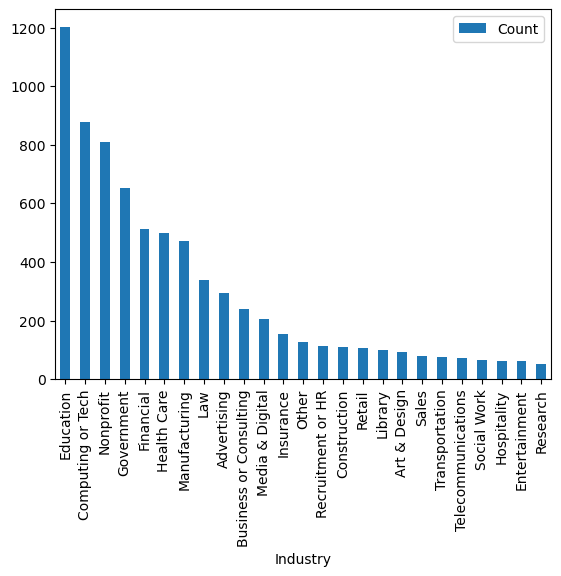

```python
industry_clean = %sql SELECT Industry, COUNT(Industry) as Count FROM survey GROUP BY Industry ORDER BY Count DESC;
industry_clean_df = industry_clean.DataFrame()


industry_clean_df.iloc[0:25,].plot('Industry','Count',kind='bar')
plt.show()
```

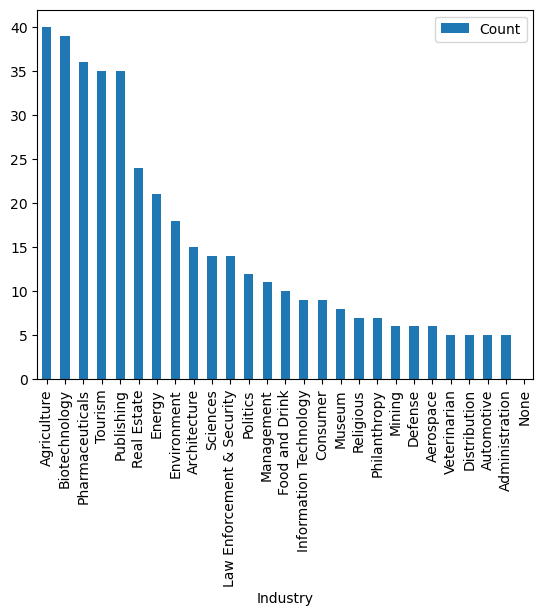

```python
industry_clean_df.iloc[25:,].plot('Industry','Count',kind='bar')
plt.show()
```

## Job

#### The next column, Job, is a lot more messy than Industry. This one is nearly 5000 distinct values. While I first attempted to use the previous method, it would be much too time-consuming.

#### I did notice that many jobs had Roman numerals behind them, which I trimmed off. This would aggregate a few of the titles.

#### Other inconsistencies came from word abbreviations, such as shortening Director to Dir, or Administrator to Admin. I used the REPLACE function to format some of these. Like I said, SQLite is limited in text formatting. This column will be saved for another project when I'll use PostgreSQL.

```python
%%sql

SELECT COUNT(DISTINCT Job)
FROM survey;
```

```
 * sqlite:///portfolioprojects.db
Done.
```

| COUNT(DISTINCT Job) |
| --- |
| 4705 |

```python
%%sql

UPDATE survey
SET Job = CASE
    WHEN Job LIKE '%teacher' THEN 'Teacher'
    WHEN Job LIKE 'Academic Adv%' THEN 'Academic Advisor'
    WHEN Job LIKE '%Hardware engineer' THEN 'Hardware Engineer'
    WHEN Job LIKE 'Academic%Coordinato%' THEN 'Academic Coordinator'
    WHEN Job LIKE '%Librarian%' THEN 'Librarian'
    WHEN Job LIKE 'Account%Manager%' THEN 'Account Manager'
    WHEN Job LIKE 'Account%Representative' THEN 'Account Representative'
    WHEN Job LIKE 'Accont Supervis%' THEN 'Account Supervisor'
    WHEN Job LIKE 'Accountan%' THEN 'Accountant'
    WHEN Job LIKE 'Actuar%' THEN 'Actuary'
    WHEN Job LIKE 'Adjunct%' THEN 'Adjunct Instructor'
    WHEN Job LIKE 'Admin Assistant%' THEN 'Admin Assistant'
    WHEN Job LIKE 'Admin Asst%' THEN 'Admin Assistant'
    WHEN Job LIKE 'Administrative Assis%' THEN 'Admin Assistant'
    ELSE Job END;
```

```
 * sqlite:///portfolioprojects.db
27976 rows affected.
```

```
[]
```

```python
%%sql

UPDATE survey
SET Job =
    REPLACE(Job, ' II', '')
```

```
 * sqlite:///portfolioprojects.db
27976 rows affected.
```

```
[]
```

```python
%%sql

UPDATE survey
SET Job =
    REPLACE(Job, ' IV', '')
```

```
 * sqlite:///portfolioprojects.db
27976 rows affected.
```

```
[]
```

```python
%%sql

UPDATE survey
SET Job =
    REPLACE(Job, 'Dir ', 'Director')
```

```
 * sqlite:///portfolioprojects.db
27976 rows affected.
```

```
[]
```

```python
%%sql

Update survey
SET Job =
    REPLACE(Job, ' III', '')
```

```
 * sqlite:///portfolioprojects.db
27976 rows affected.
```

```
[]
```

## Salary

#### The next column, Salary, is in a varchar format. Initial inspection reveals that there are some astronomically high number (one exceeding 100,000,000) and some very low numbers (numbers less than 100). The data must first be converted to numeric.

```python
%%sql

UPDATE survey
SET Salary =
    REPLACE(Salary, ',', '');
```

```
 * sqlite:///portfolioprojects.db
27976 rows affected.
```

```
[]
```

```python
%%sql

UPDATE survey
SET Salary =
    CAST(Salary AS int);
```

```
 * sqlite:///portfolioprojects.db
27976 rows affected.
```

```
[]
```

```
 * sqlite:///portfolioprojects.db
Done.
```

```
{'whiskers': [<matplotlib.lines.Line2D at 0x170e1539900>,
 'caps': [<matplotlib.lines.Line2D at 0x170e15391b0>,
 'boxes': [<matplotlib.lines.Line2D at 0x170e1539fc0>],
 'medians': [<matplotlib.lines.Line2D at 0x170e1538610>],
 'fliers': [<matplotlib.lines.Line2D at 0x170e1538490>],
 'means': []}
```

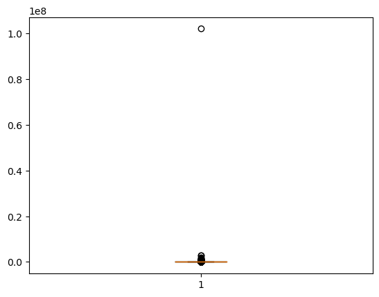

```python
salary_raw = %sql SELECT Salary FROM survey

salary_raw_df = salary_raw.DataFrame()

salary_raw_df['Salary'] = pd.to_numeric(salary_raw_df['Salary'])


plt.boxplot(salary_raw_df.dropna())
```

```
 * sqlite:///portfolioprojects.db
Done.
```

```
{'whiskers': [<matplotlib.lines.Line2D at 0x170e2829570>,
 'caps': [<matplotlib.lines.Line2D at 0x170e2828730>,
 'boxes': [<matplotlib.lines.Line2D at 0x170e28285b0>],
 'medians': [<matplotlib.lines.Line2D at 0x170e28293c0>],
 'fliers': [<matplotlib.lines.Line2D at 0x170e282a1d0>],
 'means': []}
```

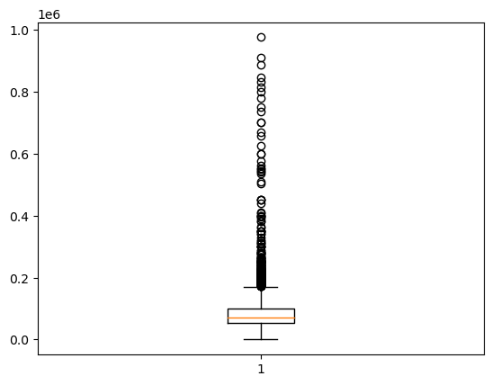

```python
salary_raw1 = %sql SELECT Salary FROM survey WHERE CAST(Salary AS int) < 1000000

salary_raw_df1 = salary_raw1.DataFrame()

salary_raw_df1['Salary'] = pd.to_numeric(salary_raw_df1['Salary'])


plt.boxplot(salary_raw_df1.dropna())
```

```
 * sqlite:///portfolioprojects.db
Done.
```

```
{'whiskers': [<matplotlib.lines.Line2D at 0x170dfab4730>,
 'caps': [<matplotlib.lines.Line2D at 0x170dfab4c70>,
 'boxes': [<matplotlib.lines.Line2D at 0x170dfab4490>],
 'medians': [<matplotlib.lines.Line2D at 0x170dfab51b0>],
 'fliers': [<matplotlib.lines.Line2D at 0x170dfab5450>],
 'means': []}
```

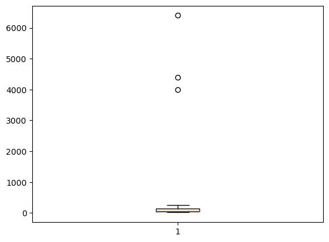

```python
salary_raw2 = %sql SELECT Salary FROM survey WHERE CAST(Salary AS int) < 10000

salary_raw_df2 = salary_raw2.DataFrame()

salary_raw_df2['Salary'] = pd.to_numeric(salary_raw_df2['Salary'])


plt.boxplot(salary_raw_df2.dropna())
```

#### After reviewing the high outliers, some things became apparent. For one, many of the high numbers are from currencies other than the US dollar. Due to exchange rates, this is not surprising. However, since I do not know anything about other currencies, I do not have a clear understanding of their accuracy.

```python
%%sql

SELECT *
FROM survey
WHERE CAST(Salary as int) > 500000
```

```
 * sqlite:///portfolioprojects.db
Done.
```

| index | Timestamp | Age | Industry | Job | Job_Description | Salary | Annual_Bonus | Currency | If "Other," please indicate the currency here: | Income_Details | Country | State | City | Overall_Experience | Industry_Experience | Education | Gender | Race |
| --- | --- | --- | --- | --- | --- | --- | --- | --- | --- | --- | --- | --- | --- | --- | --- | --- | --- | --- |
| 320 | 4/27/2021 11:08 | 25-34 | Nonprofit | Director of strategic initiatives | Project management, data, process improvement | 700000 | None | USD | None | None | United States | New York | ROCHESTER | 11 - 20 years | 5-7 years | College degree | Woman | White |
| 425 | 4/27/2021 11:09 | 45-54 | Law | Equity Partner | Equity Partner in AmLaw100 firm | 600000 | 0.0 | USD | None | Firm profits distribution; I do not have my own separate book of business | United States | Pennsylvania | Philadelphia | 21 - 30 years | 21 - 30 years | PhD | Woman | White |
| 434 | 4/27/2021 11:09 | 25-34 | Computing or Tech | Data analyst | None | 885000 | 0.0 | Other | INR | None | India | None | Pune | 2 - 4 years | 2 - 4 years | Master's degree | Woman | Asian or Asian American |
| 603 | 4/27/2021 11:12 | 45-54 | Health Care | Exec admin | Located in Argentina | 1080000 | 223000.0 | Other | Peso Argentino | Exchange about 1USD=165ARS | Argentina | None | City of Buenos Aires | 11 - 20 years | 11 - 20 years | College degree | Woman | Hispanic, Latino, or Spanish origin |
| 1449 | 4/27/2021 11:25 | 45-54 | Business or Consulting | Design Lead | My role combines Service Design, UX, Product Strategy, Design Strategy. I'm based full time at my company's clients for 6+ months at a time. | 1150000 | 0.0 | ZAR | None | Bonuses are discretionary. Haven't received one for the last 2 years. | South Africa | None | Johannesburg | 21 - 30 years | 11 - 20 years | Some college | Woman | White |
| 1905 | 4/27/2021 11:34 | 45-54 | Health Care | RN | None | 832000 | 0.0 | USD | None | None | United Stated | Washington | Spokane | 21 - 30 years | 8 - 10 years | PhD | Woman | White |
| 1924 | 4/27/2021 11:34 | 35-44 | Sales | CEO | None | 800000 | 100000.0 | Other | NOK | None | Norway | None | Oslo | 11 - 20 years | 11 - 20 years | College degree | Woman | White |
| 2054 | 4/27/2021 11:37 | 25-34 | Computing or Tech | Manager Learning & Training | None | 669500 | 3600.0 | Other | NOK | None | Norway | None | Oslo | 5-7 years | 2 - 4 years | Master's degree | Woman | Another option not listed here or prefer not to answer |
| 2124 | 4/27/2021 11:38 | 55-64 | Art & Design | Owner and CEO | None | 3000000 | None | USD | None | None | USA | New York | New York | 21 - 30 years | 21 - 30 years | Master's degree | Woman | White |
| 2555 | 4/27/2021 11:46 | 35-44 | Financial | Managing Director | None | 625000 | None | USD | None | None | United States | District of Columbia | Washington, D.C. | 11 - 20 years | 11 - 20 years | Professional degree (MD, JD, etc.) | Woman | Black or African American, Hispanic, Latino, or Spanish origin, White |
| 2637 | 4/27/2021 11:48 | 25-34 | Sales | Facilities Coordinator | Info systems management, facilities maintenance, tech support/installation | 560000 | None | USD | None | Purchase discounts offered | USA | North Carolina | Winston Salem | 1 year or less | 1 year or less | Some college | Woman | White |
| 2866 | 4/27/2021 11:53 | 25-34 | Media & Digital | SEO Specialist | None | 543000 | 20000.0 | ZAR | None | None | South Africa | None | Cape Town | 8 - 10 years | 2 - 4 years | College degree | Woman | Another option not listed here or prefer not to answer |
| 2914 | 4/27/2021 11:54 | 55-64 | Manufacturing | Brand Innovation Manager | None | 780000 | None | SEK | None | None | Sweden | None | Gothenburg | 21 - 30 years | 2 - 4 years | PhD | Woman | White |
| 3009 | 4/27/2021 11:56 | 25-34 | Sales | Realtor | Independent Realtor | 600000 | 0.0 | CAD | None | None | Canada | None | Toronto | 8 - 10 years | 2 - 4 years | College degree | Man | White |
| 3162 | 4/27/2021 12:00 | 25-34 | Health Care | IT Director | None | 1400000 | 100000.0 | Other | Dkk | None | Denmark | None | Copenhagen | 8 - 10 years | 8 - 10 years | Master's degree | Woman | White |
| 3351 | 4/27/2021 12:04 | 55-64 | Education | Universety lecturer | None | 504000 | 0.0 | SEK | None | None | Sweden | None | Västerås | 31 - 40 years | 31 - 40 years | Master's degree | Woman | White |
| 3423 | 4/27/2021 12:06 | 35-44 | Education | Education Technology Manager | None | 657900 | None | USD | None | None | United States | Tennessee | Nashville | 11 - 20 years | 5-7 years | Master's degree | Woman | White |
| 3605 | 4/27/2021 12:11 | 25-34 | Telecommunications | Operations Manager | None | 102000000 | None | USD | COP | Colombian peso - converting to usd it seems low, but in terms of local value, it is quite high | Colombia | None | Bogota | 8 - 10 years | 1 year or less | Some college | Man | Hispanic, Latino, or Spanish origin |
| 3722 | 4/27/2021 12:14 | 35-44 | Computing or Tech | Senior Researcher | Machine learning researcher | 575000 | 40000.0 | USD | None | About 60% is in stock, which changes with market | USA | California | Bay Area | 11 - 20 years | 11 - 20 years | PhD | Woman | White |
| 3937 | 4/27/2021 12:20 | 45-54 | Computing or Tech | Senior Manager | Consulting Services | 1150000 | 100000.0 | Other | NOK | None | Norway | None | Oslo | 21 - 30 years | 21 - 30 years | Master's degree | Woman | White |
| 4206 | 4/27/2021 12:27 | 25-34 | Manufacturing | Software Engineer | None | 1100000 | 0.0 | USD | None | None | USA | Pennsylvania | King of Prussia | 5-7 years | 5-7 years | Master's degree | Woman | White |
| 4499 | 4/27/2021 12:36 | 35-44 | Computing or Tech | Producer | Project management type of role | 2800000 | 230000.0 | Other | Indian rupees | None | India | None | Bangalore | 11 - 20 years | 5-7 years | College degree | Woman | Another option not listed here or prefer not to answer |
| 4971 | 4/27/2021 12:53 | 35-44 | Manufacturing | Compliance Senior Analyst | None | 534300 | 63800.0 | Other | Mexican pesos | None | Mexico | None | Mexico City | 11 - 20 years | 8 - 10 years | College degree | Woman | Hispanic, Latino, or Spanish origin |
| 5146 | 4/27/2021 12:59 | 45-54 | Other | translator/editor | None | 1100000 | None | Other | CZK | None | Czech republic | None | Prague | 21 - 30 years | 21 - 30 years | Master's degree | Woman | White |
| 5279 | 4/27/2021 13:04 | 25-34 | Advertising | Campaign Manager | None | 540000 | None | USD | None | None | USA | Colorado | Denver | 8 - 10 years | 8 - 10 years | College degree | Woman | Black or African American, Hispanic, Latino, or Spanish origin |
| 5306 | 4/27/2021 13:05 | 35-44 | Computing or Tech | Network Engineer | None | 1200000 | 120000.0 | Other | CZK | None | Czechia | None | Prague | 8 - 10 years | 8 - 10 years | Some college | Man | White |
| 5581 | 4/27/2021 13:16 | 18-24 | Agriculture | Agricultural Supply line Negotiating consultant | I buy and sell feedstock and cattle for other people | 910000 | 250000.0 | GBP | None | Bonus depends on a LOT. With covid, it took a hit to about 150, but in all other years it's been 250 | UK | None | London | 2 - 4 years | 5-7 years | Some college | Non-binary | White |
| 5729 | 4/27/2021 13:21 | 35-44 | Government | Head of administration | None | 813000 | 24000.0 | Other | NOK | None | Norway | None | Major | 11 - 20 years | 11 - 20 years | Master's degree | Woman | White |
| 5755 | 4/27/2021 13:22 | 25-34 | Health Care | Attending Physician (general internal medicine) | None | 1900000 | 0.0 | USD | None | None | USA | Connecticut | New Haven | 5-7 years | 5-7 years | Professional degree (MD, JD, etc.) | Woman | White |
| 6128 | 4/27/2021 13:36 | 25-34 | Financial | Senior AML Manager | Not my official title but the same general area | 700000 | None | Other | DKK | Plus incredible benefits - 7 weeks paid annual leave and 1 YEAR maternity leave | Denmark | None | Copenhagen | 5-7 years | 5-7 years | Master's degree | Woman | White |
| 6765 | 4/27/2021 14:06 | 25-34 | Other | Program specialist | Write proposal and concept notes, work on developing strategy for a department of a large ingo | 845000 | None | Other | Bdt | Local rate, not very high | Bangladesh | None | .. | 2 - 4 years | 2 - 4 years | None | Woman | Another option not listed here or prefer not to answer |
| 6776 | 4/27/2021 14:07 | 18-24 | Nonprofit | Admin manager | None | 750000 | None | USD | None | None | US | District of Columbia | DC | 1 year or less | 1 year or less | Some college | Woman | Hispanic, Latino, or Spanish origin |
| 6783 | 4/27/2021 14:08 | 25-34 | Computing or Tech | Principal Software Engineer | None | 1650000 | 25000.0 | USD | None | None | United States | Massachusetts | Boston | 8 - 10 years | 5-7 years | Master's degree | Man | Asian or Asian American, White |
| 6909 | 4/27/2021 14:15 | 45-54 | Media & Digital | Editor | None | 552000 | 0.0 | SEK | None | None | Sweden | None | Stockholm | 11 - 20 years | 11 - 20 years | College degree | Woman | White |
| 6968 | 4/27/2021 14:18 | 35-44 | Nonprofit | Assistant Director | None | 734400 | 0.0 | USD | None | None | U.S. | Kansas | Salina | 11 - 20 years | 8 - 10 years | College degree | Woman | White |
| 7263 | 4/27/2021 14:36 | 35-44 | Education | Associate Professor | Like an Adjunct Prof in USA | 974400 | None | ZAR | None | None | South Africa | None | Cape Town | 21 - 30 years | 11 - 20 years | Professional degree (MD, JD, etc.) | Woman | Asian or Asian American |
| 7510 | 4/27/2021 14:53 | 45-54 | Computing or Tech | Senior Manager Software Dev | None | 550000 | 0.0 | USD | None | None | USA | Washington | Seattle | 21 - 30 years | 21 - 30 years | College degree | Other or prefer not to answer | Asian or Asian American |
| 7537 | 4/27/2021 14:55 | 35-44 | Media & Digital | EA | to CEO | 510000 | 0.0 | Other | DKK | None | Denmark | None | Copenhagen | 11 - 20 years | 11 - 20 years | College degree | Woman | White |

```python
%%sql

UPDATE survey
SET Salary = '56000'
    WHERE `index` = '2637'
```

```
 * sqlite:///portfolioprojects.db
1 rows affected.
```

```
[]
```

```python
%%sql

UPDATE survey
SET Salary = '75000'
    WHERE `index` = '6776'
```

```
 * sqlite:///portfolioprojects.db
1 rows affected.
```

```
[]
```

```python
%%sql

UPDATE survey
SET Salary = '73440'
    WHERE `index` = '6968'
```

```
 * sqlite:///portfolioprojects.db
1 rows affected.
```

```
[]
```

#### The other batch of outliers lie below 1000. My initial assumption is that users input this data assuming that their 2 digit answers translated into thousands. My fix was to add three 0's to the ends of these numbers.

#### There is one caveat. I did not assume this was the case for currencies other than the USD. For those salaries, I converted the salary to 0, and then converted them to NULLs.

```python
%%sql

SELECT *
FROM survey
WHERE CAST(Salary AS int) < 1000
```

```
 * sqlite:///portfolioprojects.db
Done.
```

| index | Timestamp | Age | Industry | Job | Job_Description | Salary | Annual_Bonus | Currency | If "Other," please indicate the currency here: | Income_Details | Country | State | City | Overall_Experience | Industry_Experience | Education | Gender | Race |
| --- | --- | --- | --- | --- | --- | --- | --- | --- | --- | --- | --- | --- | --- | --- | --- | --- | --- | --- |
| 97 | 4/27/2021 11:05 | 55-64 | Environment | Quality Assurance Lead | None | 58 | None | USD | None | None | USA | Maryland | Baltimore | 21 - 30 years | 8 - 10 years | Master's degree | Woman | White |
| 166 | 4/27/2021 11:06 | 25-34 | Health Care | occupational therapist | None | 35 | None | EUR | None | None | finland | None | helsinki | 2 - 4 years | 2 - 4 years | College degree | Woman | White |
| 895 | 4/27/2021 11:16 | 45-54 | Education | Special Education Teacher | None | 38 | 0.0 | USD | None | None | USA | Idaho | Pocatello | 21 - 30 years | 11 - 20 years | Master's degree | Woman | White |
| 968 | 4/27/2021 11:17 | 25-34 | Media & Digital | Managing Editor | None | 61 | 0.0 | USD | None | None | United States | Maryland | Bethesda | 5-7 years | 5-7 years | College degree | Woman | White |
| 1607 | 4/27/2021 11:28 | 25-34 | Agriculture | Chief Data Scientist | None | 130 | 0.0 | USD | None | None | USA | New Mexico | Santa Fe | 8 - 10 years | 8 - 10 years | PhD | Woman | White |
| 2229 | 4/27/2021 11:40 | 25-34 | Advertising | Project Manager / Account Manager | None | 33 | 0.0 | EUR | None | Before tax, insurance etc. | Germany | None | Munich | 5-7 years | 2 - 4 years | Master's degree | Woman | White |
| 4081 | 4/27/2021 12:24 | 45-54 | Retail | Operations Manager | None | 35 | 0.0 | USD | None | None | US | West Virginia | Charleston | 31 - 40 years | 5-7 years | Some college | Woman | White |
| 4124 | 4/27/2021 12:25 | 35-44 | Manufacturing | Engineering Supervisor | None | 108 | 5000.0 | USD | None | None | USA | Minnesota | Twin Cities | 11 - 20 years | 8 - 10 years | College degree | Woman | White |
| 4546 | 4/27/2021 12:38 | 35-44 | Computing or Tech | Senior Developer / Consultant | None | 63 | 10.0 | EUR | None | None | Germany | None | Dortmund | 8 - 10 years | 8 - 10 years | Some college | Man | White |
| 5139 | 4/27/2021 12:59 | 35-44 | Business or Consulting | Change Management Consultant | None | 118 | None | CAD | None | None | Canada | None | Vancouver | 8 - 10 years | 8 - 10 years | College degree | Woman | White |
| 5211 | 4/27/2021 13:01 | 25-34 | Museum | Assistant Registrar | Museum Collections Management. We handle museum object storage, exhibition loans, collections acquisitions. | 40 | 0.0 | USD | None | None | USA | District of Columbia | Washington | 2 - 4 years | 2 - 4 years | Master's degree | Woman | White |
| 5879 | 4/27/2021 13:26 | 25-34 | Computing or Tech | Programmer | None | 18 | None | EUR | None | None | Netherlands | None | Enschede | 1 year or less | 1 year or less | None | Man | White |
| 6124 | 4/27/2021 13:36 | 45-54 | Library | Regional Manager | My library system has 16 locations. 1 Central location, 4 regionals, and the rest are neighborhood or minibranches. I'm a level above a regular branch manager. | 70 | 0.0 | USD | None | None | United States | Missouri | St. Louis | 21 - 30 years | 11 - 20 years | Master's degree | Woman | White |
| 6294 | 4/27/2021 13:44 | 45-54 | Telecommunications | Head of Business Support | None | 50 | 0.0 | GBP | None | None | UK | None | Manchester | 21 - 30 years | 21 - 30 years | Some college | Woman | White |
| 6550 | 4/27/2021 13:55 | 35-44 | Education | Manager | Consulting project manager | 155 | 0.0 | USD | None | None | usa | Massachusetts | Boston | 11 - 20 years | 8 - 10 years | Master's degree | Woman | White |
| 6929 | 4/27/2021 14:16 | 55-64 | Agriculture | Technician | None | 52 | 0.0 | CAD | None | None | Canada | None | Fraser valley | 31 - 40 years | 11 - 20 years | Some college | Woman | White |
| 7545 | 4/27/2021 14:55 | 25-34 | Manufacturing | Administrative Assistant | Travel Coordinator | 264 | 167.0 | Other | Php | None | Philippines | None | Batangas | 5-7 years | 5-7 years | College degree | Woman | Asian or Asian American |

```python
%%sql

UPDATE survey
SET Salary = Salary || '000'
WHERE CAST(Salary AS int) < 1000
    AND Currency = 'USD';
```

```
 * sqlite:///portfolioprojects.db
9 rows affected.
```

```
[]
```

```python
%%sql

UPDATE survey
SET Salary = '0'
WHERE CAST(Salary AS int) < 1000
```

```
 * sqlite:///portfolioprojects.db
8 rows affected.
```

```
[]
```

```python
%%sql

UPDATE survey
SET Salary = NULLIF(Salary, '0')
```

```
 * sqlite:///portfolioprojects.db
27976 rows affected.
```

```
[]
```